# **Problem Statement**

## **Business Context**

Workplace safety in hazardous environments like construction sites and industrial plants is crucial to prevent accidents and injuries. One of the most important safety measures is ensuring workers wear safety helmets, which protect against head injuries from falling objects and machinery. Non-compliance with helmet regulations increases the risk of serious injuries or fatalities, making effective monitoring essential, especially in large-scale operations where manual oversight is prone to errors and inefficiency.

To overcome these challenges, SafeGuard Corp plans to develop an automated image analysis system capable of detecting whether workers are wearing safety helmets. This system will improve safety enforcement, ensuring compliance and reducing the risk of head injuries. By automating helmet monitoring, SafeGuard aims to enhance efficiency, scalability, and accuracy, ultimately fostering a safer work environment while minimizing human error in safety oversight.

## **Objective**

As a data scientist at SafeGuard Corp, you are tasked with developing an image classification model that classifies images into one of two categories:

- **With Helmet:** Workers wearing safety helmets.
- **Without Helmet:** Workers not wearing safety helmets.

## **Data Description**

The dataset consists of **4125 images**, divided into two categories:

- **With Helmet:** 3161 images showing workers wearing helmets.
- **Without Helmet:** 964 images showing workers not wearing helmets.

**Dataset Characteristics:**

- **Variations in Conditions:** Images include diverse environments such as construction sites, factories, and industrial settings, with variations in lighting, angles, and worker postures to simulate real-world conditions.
- **Worker Activities:** Workers are depicted in different actions such as standing, using tools, or moving, ensuring robust model learning for various scenarios.

# **Installing and Importing the Necessary Libraries**

```python
!pip install tensorflow[and-cuda] scikit-learn==1.6.1 opencv-python==4.12.0.88 seaborn==0.13.2 matplotlib==3.10.0 numpy==2.0.2 pandas==2.2.2 -q
```

[output not shown]

**Note:**

- After running the above cell, kindly restart the notebook kernel (for Jupyter Notebook) or runtime (for Google Colab) and run all cells sequentially from the next cell.
- On executing the above line of code, you might see a warning regarding package dependencies. This error message can be ignored as the above code ensures that all necessary libraries and their dependencies are maintained to successfully execute the code in this notebook.

```python
import os
import random
import numpy as np                                                                               # Importing numpy for Matrix Operations
import pandas as pd
import seaborn as sns
import matplotlib.image as mpimg                                                                 # Importing pandas to read CSV files
import matplotlib.pyplot as plt                                                                  # Importting matplotlib for Plotting and visualizing images
import math                                                                                      # Importing math module to perform mathematical operations
import cv2


# Tensorflow modules
import keras
import tensorflow as tf
from sklearn.utils.class_weight import compute_class_weight
from tensorflow.keras.preprocessing.image import ImageDataGenerator                              # Importing the ImageDataGenerator for data augmentation
from tensorflow.keras.models import Sequential                                                   # Importing the sequential module to define a sequential model
from tensorflow.keras.layers import GlobalAveragePooling2D, Dense,Dropout,Flatten,Conv2D,MaxPooling2D,BatchNormalization # Defining all the layers to build our CNN Model
from tensorflow.keras.callbacks import EarlyStopping
from tensorflow.keras.optimizers import Adam,SGD                                                 # Importing the optimizers which can be used in our model
from sklearn import preprocessing                                                                # Importing the preprocessing module to preprocess the data
from sklearn.model_selection import train_test_split                                             # Importing train_test_split function to split the data into train and test
from sklearn.metrics import confusion_matrix
from tensorflow.keras.models import Model
from keras.applications.vgg16 import VGG16                                                       # Importing confusion_matrix to plot the confusion matrix

# Display images using OpenCV
from google.colab.patches import cv2_imshow

#Imports functions for evaluating the performance of machine learning models
from sklearn.metrics import confusion_matrix, f1_score,accuracy_score, recall_score, precision_score, classification_report
from sklearn.metrics import mean_squared_error as mse                                            # Importing cv2_imshow from google.patches to display images

# Ignore warnings
import warnings
warnings.filterwarnings('ignore')
```

```python
print("Num GPUs Available:", len(tf.config.list_physical_devices('GPU')))
print(tf.__version__)
```

```
Num GPUs Available: 1
2.19.0
```

# **Setting Random State**

```python
def reset_random_state(seed=812):
    # Set the Python built-in random seed for reproducible random values
    random.seed(seed)

    # Set the NumPy random seed for reproducible NumPy operations
    np.random.seed(seed)

    # Set the TensorFlow and Keras random seed for reproducible model behavior
    tf.keras.utils.set_random_seed(seed)

    # Enable deterministic GPU operations for more reproducible results
    tf.config.experimental.enable_op_determinism()

    # Clear the current TensorFlow/Keras session to remove old models and graphs
    tf.keras.backend.clear_session()
```

```python
# Reset random state for this notebook
reset_random_state()
```

# **Data Overview**

## Loading the data

```python
# Mount the google drive
from google.colab import drive
drive.mount('/content/drive')

# Load images
images = np.load('/content/drive/MyDrive/ColabNotebooks/HelmNet/images.npy')
# Check shape of the images array
print(f"Shape of the image dataset is {images.shape}")

# Load labels
labels = pd.read_csv('/content/drive/MyDrive/ColabNotebooks/HelmNet/labels.csv')
# Check shape of the labels data frame
print(f"Shape of the label dataset is {labels.shape}")
```

```
Shape of the image dataset is (4125, 200, 200, 3)
Shape of the label dataset is (4125, 1)
```

- The dataset was loaded successfully.
- The image dataset contains 4125 images, each with a size of 200 × 200 pixels and 3 color channels, indicating that the images are in RGB format.
- The labels file contains 4125 corresponding entries with one target column. Since the number of images matches the number of labels, the dataset is properly aligned for further analysis.

# **Exploratory Data Analysis**

```python
# Print the columns from the labels dataset
print(labels.columns)
```

```
Index(['label'], dtype='object')
```

## Checking for class imbalance

```
label
1    3161
0     964
Name: count, dtype: int64
```

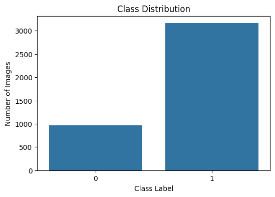

```python
# Count the number of samples in each class
class_counts = labels['label'].value_counts()
print(class_counts)

# Plot class distribution
plt.figure(figsize=(6, 4))
sns.countplot(x=labels['label'])
plt.title("Class Distribution")
plt.xlabel("Class Label")
plt.ylabel("Number of Images")
plt.show()
```

- The class distribution indicates a significant imbalance in the dataset. Out of 4125 total images, 3161 belong to class 1 and 964 belong to class 0. This means the model may become biased toward predicting the majority class more often. Therefore, while building and evaluating models, it is important to use metrics such as precision, recall, and F1-score in addition to accuracy.
- The imbalance suggests that special care may be needed during modeling, such as using class weights, data augmentation, or closely monitoring minority-class performance.

### Plot random images from each of the classes and print their corresponding labels.

```
Unique labels in the label dataset are [0 1]

Random samples from class 0 (Without Helmet):
Image index: 211, Label: 0 (Without Helmet)
Image index: 911, Label: 0 (Without Helmet)
Image index: 683, Label: 0 (Without Helmet)

Random samples from class 1 (With Helmet):
Image index: 2606, Label: 1 (With Helmet)
Image index: 2668, Label: 1 (With Helmet)
Image index: 2398, Label: 1 (With Helmet)
```

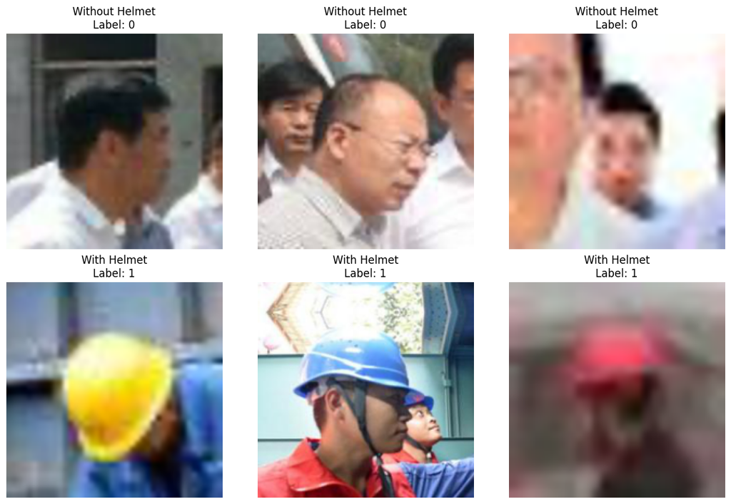

```python
# Check unique labels first
print(f"Unique labels in the label dataset are {labels['label'].unique()}")

# Convert labels to NumPy array
label_array = labels['label'].values

# Get unique classes
classes = np.unique(label_array)

# Assign names to each class
class_names = {1: 'With Helmet', 0: 'Without Helmet'}

# Plot 3 random images from each class
plt.figure(figsize=(12, 8))

plot_index = 1
for cls in classes:
    class_indices = np.where(label_array == cls)[0]
    random_indices = np.random.choice(class_indices, 3, replace=False)

    print(f"\nRandom samples from class {cls} ({class_names[cls]}):")

    for idx in random_indices:
        print(f"Image index: {idx}, Label: {label_array[idx]} ({class_names[label_array[idx]]})")

        plt.subplot(len(classes), 3, plot_index)
        plt.imshow(images[idx])
        plt.title(f"{class_names[label_array[idx]]}\nLabel: {label_array[idx]}")
        plt.axis('off')
        plot_index += 1

plt.tight_layout()
plt.show()
```

- Random images from each class were plotted to visually inspect the dataset.
- This step helps verify that the images and labels are correctly matched and provides an initial understanding of differences between the two classes, such as the presence or absence of safety helmets, along with variations in pose, background, and lighting.

# **Data Preprocessing**

### Resizing images

As the size of the images is large (200x200), it may be computationally expensive to train on these larger images. Therefore, it is preferable to reduce the image size from 200 to 64.

```python
resized_images = []
height = 64
width = 64
dimensions = (width, height)
for i in range(len(images)):
  resized_images.append(cv2.resize(images[i], dimensions, interpolation=cv2.INTER_LINEAR))
```

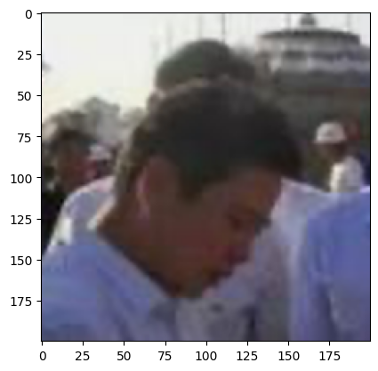

```python
# Show original image
plt.imshow(images[8]);
```

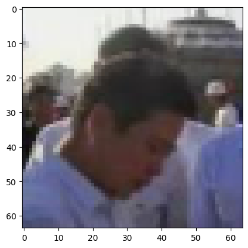

```python
# Show resized image
plt.imshow(resized_images[8]);
```

- As shown in the image, the resized image still contains the feature that will be used in the model training. However, now that the size of the images are reduced, the model training will not be computationally expensive.

### Splitting the dataset

```python
# Convert resized images list to NumPy array
resized_images = np.array(resized_images)

# Check the new shape
print("Resized images shape:", resized_images.shape)
print("Labels shape:", label_array.shape)

# Features and labels
X = resized_images
y = labels['label'].values

# First split: train and temp
X_train, X_temp, y_train, y_temp = train_test_split(
    X, y,
    test_size=0.30,
    random_state=42,
    stratify=y
)

# Second split: validation and test
X_val, X_test, y_val, y_test = train_test_split(
    X_temp, y_temp,
    test_size=0.50,
    random_state=42,
    stratify=y_temp
)

# Check shapes
print("Training set:", X_train.shape, y_train.shape)
print("Validation set:", X_val.shape, y_val.shape)
print("Test set:", X_test.shape, y_test.shape)

# Check class distribution
print("Train class distribution:\n", pd.Series(y_train).value_counts(normalize=True))
print("Validation class distribution:\n", pd.Series(y_val).value_counts(normalize=True))
print("Test class distribution:\n", pd.Series(y_test).value_counts(normalize=True))
```

```
Resized images shape: (4125, 64, 64, 3)
Labels shape: (4125,)
Training set: (2887, 64, 64, 3) (2887,)
Validation set: (619, 64, 64, 3) (619,)
Test set: (619, 64, 64, 3) (619,)
Train class distribution:
 1    0.766193
0    0.233807
Name: proportion, dtype: float64
Validation class distribution:
 1    0.767367
0    0.232633
Name: proportion, dtype: float64
Test class distribution:
 1    0.765751
0    0.234249
Name: proportion, dtype: float64
```

- The dataset was split into training, validation, and test sets using stratified sampling.
- The training set contains 2887 images, while the validation and test sets each contain 619 images.
- The class proportions remain nearly identical across all three subsets, with about 76.7% of samples in class 1 and 23.3% in class 0.
- This confirms that the original class imbalance was preserved during splitting, which is important for fair model training and evaluation.
- Preserving the same class distribution across all subsets is especially important here because the dataset is imbalanced. Without stratification, one subset might contain too few minority-class samples, which could lead to unreliable validation or test results.

### Data Normalization

```python
# Normalize image pixel values
X_train_normalized = X_train.astype('float32') / 255.0
X_val_normalized = X_val.astype('float32') / 255.0
X_test_normalized = X_test.astype('float32') / 255.0

# Check the range after normalization
print("Train normalized min:", X_train_normalized.min(), "Train normalized max:", X_train_normalized.max())
print("Validation normalized min:", X_val_normalized.min(), "Validation normalized max:", X_val_normalized.max())
print("Test normalized min:", X_test_normalized.min(), "Test normalized max:", X_test_normalized.max())
```

```
Train normalized min: 0.0 Train normalized max: 1.0
Validation normalized min: 0.0 Validation normalized max: 1.0
Test normalized min: 0.0 Test normalized max: 1.0
```

- The image data was normalized by dividing pixel values by 255 so that all values fall between 0 and 1. Normalization helps improve model training by making the input scale consistent, which leads to more stable and efficient optimization.

# **Model Building**

## Model Evaluation Criterion

Since this is a binary classification problem, the model will be evaluated using Accuracy, Precision, Recall, and F1-score, along with the confusion matrix. Accuracy shows the overall proportion of correct predictions, while precision, recall, and F1-score provide a better understanding of class-wise performance. This is especially important because the dataset is imbalanced, with many more images in the helmet class than in the non-helmet class. The confusion matrix will help identify how well the model distinguishes between workers wearing helmets and workers not wearing helmets.

## Utility Functions

```python
from sklearn.metrics import accuracy_score, recall_score, precision_score, f1_score, confusion_matrix

def model_performance_classification(model, predictors, target):
    """
    Evaluate binary classification model performance

    model: trained classifier
    predictors: input features
    target: true binary labels (0 or 1)
    """

    # Predicted probabilities
    pred_prob = model.predict(predictors)

    # Convert probabilities to class labels
    pred = (pred_prob > 0.5).astype("int32").flatten()

    acc = accuracy_score(target, pred)
    recall = recall_score(target, pred)
    precision = precision_score(target, pred)
    f1 = f1_score(target, pred)

    df_perf = pd.DataFrame({
        "Accuracy": [acc],
        "Recall": [recall],
        "Precision": [precision],
        "F1 Score": [f1]
    })

    return df_perf
```

```python
from sklearn.metrics import confusion_matrix

def plot_confusion_matrix(model, predictors, target, title="Confusion Matrix"):
    """
    Plot confusion matrix for binary classification.

    model: trained model
    predictors: input features
    target: true labels (0 or 1)
    title: plot title
    """
    pred_prob = model.predict(predictors)
    pred = (pred_prob > 0.5).astype("int32").flatten()

    cm = confusion_matrix(target, pred)

    plt.figure(figsize=(6, 5))
    sns.heatmap(
        cm,
        annot=True,
        fmt="d",
        cmap="Blues",
        xticklabels=["Without Helmet", "With Helmet"],
        yticklabels=["Without Helmet", "With Helmet"]
    )
    plt.xlabel("Predicted Label")
    plt.ylabel("True Label")
    plt.title(title)
    plt.show()
```

```python
def plot_training_history(history, title="Model Training History"):
    """
    Plot training and validation accuracy and loss across epochs.

    history: History object returned by model.fit()
    title: title prefix for the plots
    """
    plt.figure(figsize=(12, 5))

    # Accuracy plot
    plt.subplot(1, 2, 1)
    plt.plot(history.history['accuracy'], label='Train Accuracy')
    plt.plot(history.history['val_accuracy'], label='Validation Accuracy')
    plt.title(f'{title} - Accuracy')
    plt.xlabel('Epoch')
    plt.ylabel('Accuracy')
    plt.legend()

    # Loss plot
    plt.subplot(1, 2, 2)
    plt.plot(history.history['loss'], label='Train Loss')
    plt.plot(history.history['val_loss'], label='Validation Loss')
    plt.title(f'{title} - Loss')
    plt.xlabel('Epoch')
    plt.ylabel('Loss')
    plt.legend()

    plt.tight_layout()
    plt.show()
```

```python
def evaluate_model_on_datasets(model, X_train, y_train, X_val, y_val, model_name="Model"):
    """
    Evaluate model on training and validation sets, plot confusion matrices,
    and return a combined performance table.
    """
    train_perf = model_performance_classification(model, X_train, y_train)
    train_perf.index = ['Train']

    val_perf = model_performance_classification(model, X_val, y_val)
    val_perf.index = ['Validation']

    performance_comparison = pd.concat([train_perf, val_perf])

    print(f"{model_name} Performance Summary")
    display(performance_comparison.round(4))

    plot_confusion_matrix(model, X_train, y_train, title=f"{model_name} - Training Confusion Matrix")
    plot_confusion_matrix(model, X_val, y_val, title=f"{model_name} - Validation Confusion Matrix")

    return performance_comparison
```

```python
# Stop training early if the validation loss does not improve
# for 3 consecutive epochs. This helps prevent overfitting.
# restore_best_weights=True reloads the model weights from the
# epoch with the lowest validation loss after training ends.
early_stopping = EarlyStopping(
    monitor='val_loss',
    patience=3,
    restore_best_weights=True
)
```

```python
def plot_two_predictions(idx1, idx2, X_display, X_input, y_true, model):
    """
    Plot two images and show predicted vs true labels.

    idx1, idx2 : indices of images to display
    X_display  : original images for visualization
    X_input    : preprocessed images to be used for prediction
                 - X_val_normalized for CNN
                 - X_val_vgg for VGG-based models
    y_true     : true labels
    model      : trained model
    """
    indices = [idx1, idx2]

    fig, axes = plt.subplots(1, 2, figsize=(6, 4))

    for ax, idx in zip(axes, indices):
        # Show the original image
        ax.imshow(X_display[idx])
        ax.axis("off")

        # Predict using the correctly preprocessed input
        prediction = model.predict(
            X_input[idx].reshape(1, 64, 64, 3),
            verbose=0
        )

        predicted_label = 1 if prediction[0][0] > 0.5 else 0
        true_label = y_true[idx]

        ax.text(
            0.5, -0.15,
            f"Index: {idx}\nPredicted: {predicted_label}\nTrue: {true_label}",
            transform=ax.transAxes,
            ha="center",
            va="top",
            fontsize=10
        )

    plt.tight_layout()
    plt.show()
```

- The utility functions were modified because the project is a binary classification problem, where labels are stored as 0 and 1, and the model predicts a single probability using a sigmoid output layer. The original helper methods used argmax(), which is suitable for multi-class classification or one-hot encoded labels, not for binary labels.
- In this project, predictions must be converted into class labels using a threshold such as 0.5, so the helper methods were updated to correctly evaluate binary outputs and produce accurate performance metrics and confusion matrices.

## Model 1: Convolutional Neural Network (CNN) from Scratch

Let us first build a CNN model from scratch for the helmet classification task. The model has two main parts:

1. Feature Extraction Layers These consist of convolutional layers and max-pooling layers. The convolutional layers help the model learn important visual patterns such as edges, shapes, and helmet-related features, while the pooling layers reduce the spatial dimensions and help make the model more efficient.
2. Fully Connected Classification Layers After feature extraction, the learned feature maps are flattened and passed through dense layers. These layers use the extracted features to classify each image into one of the two categories: With Helmet or Without Helmet.

```
Model: "sequential"
```

```
┏━━━━━━━━━━━━━━━━━━━━━━━━━━━━━━━━━┳━━━━━━━━━━━━━━━━━━━━━━━━┳━━━━━━━━━━━━━━━┓
┃ Layer (type)                    ┃ Output Shape           ┃       Param # ┃
┡━━━━━━━━━━━━━━━━━━━━━━━━━━━━━━━━━╇━━━━━━━━━━━━━━━━━━━━━━━━╇━━━━━━━━━━━━━━━┩
│ conv2d (Conv2D)                 │ (None, 64, 64, 16)     │           448 │
├─────────────────────────────────┼────────────────────────┼───────────────┤
│ max_pooling2d (MaxPooling2D)    │ (None, 32, 32, 16)     │             0 │
├─────────────────────────────────┼────────────────────────┼───────────────┤
│ conv2d_1 (Conv2D)               │ (None, 32, 32, 32)     │         4,640 │
├─────────────────────────────────┼────────────────────────┼───────────────┤
│ max_pooling2d_1 (MaxPooling2D)  │ (None, 16, 16, 32)     │             0 │
├─────────────────────────────────┼────────────────────────┼───────────────┤
│ conv2d_2 (Conv2D)               │ (None, 16, 16, 64)     │        18,496 │
├─────────────────────────────────┼────────────────────────┼───────────────┤
│ flatten (Flatten)               │ (None, 16384)          │             0 │
├─────────────────────────────────┼────────────────────────┼───────────────┤
│ dense (Dense)                   │ (None, 32)             │       524,320 │
├─────────────────────────────────┼────────────────────────┼───────────────┤
│ dropout (Dropout)               │ (None, 32)             │             0 │
├─────────────────────────────────┼────────────────────────┼───────────────┤
│ dense_1 (Dense)                 │ (None, 1)              │            33 │
└─────────────────────────────────┴────────────────────────┴───────────────┘
```

```
 Total params: 547,937 (2.09 MB)
```

```
 Trainable params: 547,937 (2.09 MB)
```

```
 Non-trainable params: 0 (0.00 B)
```

```
Class weights: {np.int64(0): np.float64(2.1385185185185187), np.int64(1): np.float64(0.6525768535262206)}
91/91 - 6s - 67ms/step - accuracy: 0.7437 - loss: 0.6422 - val_accuracy: 0.8465 - val_loss: 0.4708
91/91 - 1s - 9ms/step - accuracy: 0.8133 - loss: 0.4831 - val_accuracy: 0.8691 - val_loss: 0.3389
91/91 - 1s - 9ms/step - accuracy: 0.8549 - loss: 0.3925 - val_accuracy: 0.8772 - val_loss: 0.3001
91/91 - 1s - 9ms/step - accuracy: 0.8684 - loss: 0.3437 - val_accuracy: 0.8901 - val_loss: 0.2554
91/91 - 1s - 9ms/step - accuracy: 0.8770 - loss: 0.3143 - val_accuracy: 0.8966 - val_loss: 0.2382
91/91 - 1s - 11ms/step - accuracy: 0.8888 - loss: 0.2921 - val_accuracy: 0.9031 - val_loss: 0.2292
91/91 - 1s - 10ms/step - accuracy: 0.8937 - loss: 0.2892 - val_accuracy: 0.9063 - val_loss: 0.2226
91/91 - 1s - 13ms/step - accuracy: 0.8961 - loss: 0.2695 - val_accuracy: 0.9015 - val_loss: 0.2292
91/91 - 1s - 12ms/step - accuracy: 0.9023 - loss: 0.2422 - val_accuracy: 0.9015 - val_loss: 0.2248
91/91 - 2s - 25ms/step - accuracy: 0.9044 - loss: 0.2353 - val_accuracy: 0.9047 - val_loss: 0.2131
```

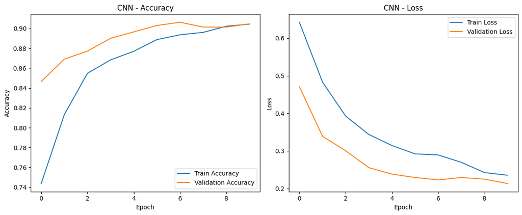

```
91/91 ━━━━━━━━━━━━━━━━━━━━ 1s 8ms/step
20/20 ━━━━━━━━━━━━━━━━━━━━ 0s 5ms/step
CNN Performance Summary
```

|  | Accuracy | Recall | Precision | F1 Score |
| --- | --- | --- | --- | --- |
| Train | 0.9245 | 0.9241 | 0.9761 | 0.9494 |
| Validation | 0.9047 | 0.9074 | 0.9664 | 0.9359 |

```
91/91 ━━━━━━━━━━━━━━━━━━━━ 1s 4ms/step
```

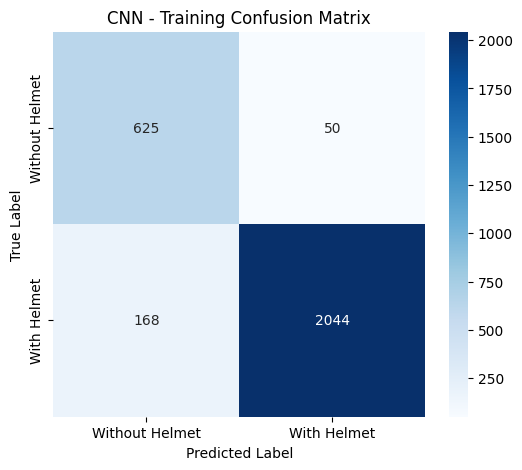

```
20/20 ━━━━━━━━━━━━━━━━━━━━ 0s 5ms/step
```

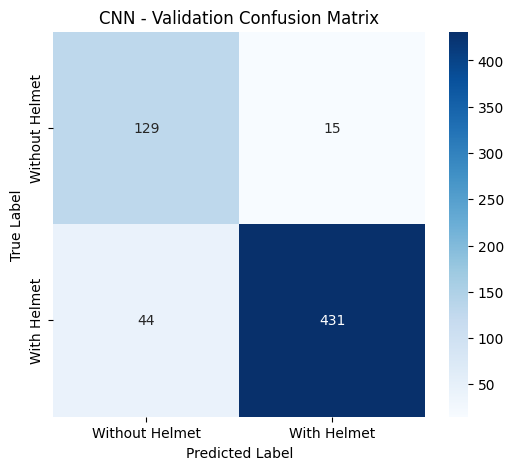

```python
# Reset random state for this notebook
reset_random_state()

# Initialize a Sequential CNN model
model_1 = Sequential()

# Add the first convolutional layer to extract low-level image features
model_1.add(Conv2D(16, (3, 3), activation='relu', padding='same', input_shape=(64, 64, 3)))

# Downsample the feature maps to reduce dimensionality
model_1.add(MaxPooling2D((2, 2), padding='same'))

# Add a second convolutional layer to learn more complex patterns
model_1.add(Conv2D(32, (3, 3), activation='relu', padding='same'))

# Further reduce the spatial dimensions
model_1.add(MaxPooling2D((2, 2), padding='same'))

# Add a third convolutional layer for deeper feature extraction
model_1.add(Conv2D(64, (3, 3), activation='relu', padding='same'))

# Flatten the 2D feature maps into a 1D vector
model_1.add(Flatten())

# Add a fully connected hidden layer
model_1.add(Dense(32, activation='relu'))

# Add dropout to reduce overfitting
model_1.add(Dropout(0.3))

# Add the output layer with sigmoid activation for binary classification
model_1.add(Dense(1, activation='sigmoid'))

# Define the Adam optimizer with a learning rate of 0.0001
opt = Adam(learning_rate=0.0001)

# Compile the model using binary crossentropy loss and accuracy metric
model_1.compile(
    optimizer=opt,
    loss='binary_crossentropy',
    metrics=['accuracy']
)

# Display the model architecture summary
model_1.summary()

# Compute class weights to handle class imbalance
classes = np.unique(y_train)
class_weights = compute_class_weight(
    class_weight='balanced',
    classes=classes,
    y=y_train
)

class_weight_dict = dict(zip(classes, class_weights))
print("Class weights:", class_weight_dict)

# Train the CNN model on the normalized training data
history_1 = model_1.fit(
    X_train_normalized,
    y_train,
    epochs=10,
    validation_data=(X_val_normalized, y_val),
    shuffle=True,
    batch_size=32,
    class_weight=class_weight_dict,
    callbacks=[early_stopping],
    verbose=2
)

# Plot training history using helper method
plot_training_history(history_1, title="CNN")

# Evaluate performance on the training and validation set
performance_model_1 = evaluate_model_on_datasets(
    model=model_1,
    X_train=X_train_normalized,
    y_train=y_train,
    X_val=X_val_normalized,
    y_val=y_val,
    model_name="CNN"
)
```

## **Why these values were chosen**

The values for Model 1 were selected to create a simple baseline CNN that could learn useful visual features from the resized 64 × 64 helmet images while keeping the architecture computationally manageable. Three convolutional layers with 16, 32, and 64 filters were used so the model could progressively learn low-level, intermediate, and deeper image patterns. The 3 × 3 kernel size was chosen because it is a standard and effective choice for capturing local image features. ReLU activation was used in the hidden layers to introduce non-linearity and improve learning efficiency.

MaxPooling2D layers were added to reduce spatial dimensions and help the model focus on the most important features while lowering computational cost. A dense layer with 32 units was included to combine the extracted features before the final prediction. Dropout(0.3) was used to reduce overfitting by randomly dropping some neurons during training. Since this is a binary classification problem with labels 0 and 1, the output layer uses 1 neuron with sigmoid activation, which produces a probability for the positive class.

The Adam optimizer with learning rate 0.0001 was chosen because it is widely used and performs well for CNN training. The loss function binary_crossentropy was selected because it matches binary classification tasks. Class weights were applied to reduce the effect of class imbalance and make the model pay more attention to the minority class. Early stopping was also used to prevent overfitting by stopping training when validation performance no longer improved.

## **Short summary**

Model 1 (CNN from scratch) performed well on both the training and validation sets, showing strong overall classification ability. The training and validation results are close to each other, which suggests good generalization with no major overfitting.

The confusion matrices also indicate that the model correctly classified most images in both classes, with especially strong performance on the With Helmet class. On the validation set, the CNN achieved 90.47% accuracy, 90.74% recall, 96.64% precision, and an F1-score of 93.59%, confirming that this baseline model is reliable and effective for helmet detection.

### Visualizing the predictions

```python
# Visualizing predictions for index 12 and 30
plot_two_predictions(12, 30, X_val, X_val_normalized, y_val, model_1)
```

[output not shown]

## VGG-16 Model

For the Models from 2 to 4, I have used `preprocess_input` was used to prepare the images in the same way that VGG-16 expects.

VGG-16 was originally trained on ImageNet images, so its input data must be processed with the same preprocessing function used during that original training. This function adjusts the pixel values to the format expected by the pre-trained network, which helps the model extract features correctly.

Without using preprocess_input, the image values would not match the distribution VGG-16 was trained on, and the model’s performance could become worse. So, it was applied to make the transfer learning models work properly and give more reliable results.

## Model 2: Transfer Learning with VGG-16 (Base)

Let us now build a transfer learning model using VGG-16 as the base model. Instead of training a CNN entirely from scratch, we use the convolutional base of the pre-trained VGG-16 model, which has already learned rich image features from the ImageNet dataset.

The model has two main parts:

1. Pre-trained Feature Extraction Layers These are the convolutional layers of the VGG-16 model. Since these layers have already learned useful visual patterns such as edges, textures, and object shapes, they can be used as a strong feature extractor for this image classification task. In this model, these layers are frozen so their weights are not updated during training.
2. Classification Layer After extracting features using the VGG-16 base, the output is flattened and passed to a final dense layer with sigmoid activation. This layer performs the binary classification and predicts whether a worker is wearing a helmet or not.

Transfer learning is useful here because the VGG-16 model has already learned general visual features from a very large dataset, which can improve performance and reduce training time compared with building a model entirely from scratch.

```
Downloading data from https://storage.googleapis.com/tensorflow/keras-applications/vgg16/vgg16_weights_tf_dim_ordering_tf_kernels_notop.h5
58889256/58889256 ━━━━━━━━━━━━━━━━━━━━ 0s 0us/step
```

```
Model: "sequential"
```

```
┏━━━━━━━━━━━━━━━━━━━━━━━━━━━━━━━━━┳━━━━━━━━━━━━━━━━━━━━━━━━┳━━━━━━━━━━━━━━━┓
┃ Layer (type)                    ┃ Output Shape           ┃       Param # ┃
┡━━━━━━━━━━━━━━━━━━━━━━━━━━━━━━━━━╇━━━━━━━━━━━━━━━━━━━━━━━━╇━━━━━━━━━━━━━━━┩
│ vgg16 (Functional)              │ (None, 2, 2, 512)      │    14,714,688 │
├─────────────────────────────────┼────────────────────────┼───────────────┤
│ flatten (Flatten)               │ (None, 2048)           │             0 │
├─────────────────────────────────┼────────────────────────┼───────────────┤
│ dense (Dense)                   │ (None, 32)             │        65,568 │
├─────────────────────────────────┼────────────────────────┼───────────────┤
│ dropout (Dropout)               │ (None, 32)             │             0 │
├─────────────────────────────────┼────────────────────────┼───────────────┤
│ dense_1 (Dense)                 │ (None, 1)              │            33 │
└─────────────────────────────────┴────────────────────────┴───────────────┘
```

```
 Total params: 14,780,289 (56.38 MB)
```

```
 Trainable params: 65,601 (256.25 KB)
```

```
 Non-trainable params: 14,714,688 (56.13 MB)
```

```
Class weights: {np.int64(0): np.float64(2.1385185185185187), np.int64(1): np.float64(0.6525768535262206)}
91/91 - 4s - 45ms/step - accuracy: 0.6793 - loss: 3.1589 - val_accuracy: 0.8433 - val_loss: 0.9648
91/91 - 3s - 30ms/step - accuracy: 0.8195 - loss: 1.2100 - val_accuracy: 0.8853 - val_loss: 0.6365
91/91 - 3s - 27ms/step - accuracy: 0.8729 - loss: 0.7540 - val_accuracy: 0.8950 - val_loss: 0.5267
```

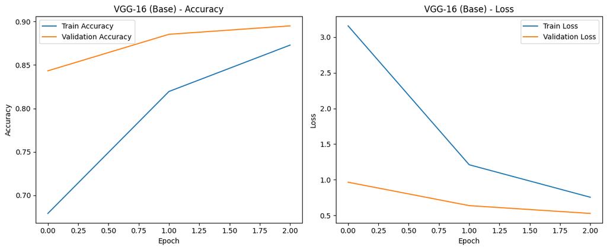

```
91/91 ━━━━━━━━━━━━━━━━━━━━ 3s 26ms/step
20/20 ━━━━━━━━━━━━━━━━━━━━ 0s 15ms/step
VGG-16 (Base) Performance Summary
```

|  | Accuracy | Recall | Precision | F1 Score |
| --- | --- | --- | --- | --- |
| Train | 0.8421 | 0.8481 | 0.9399 | 0.8916 |
| Validation | 0.8433 | 0.8358 | 0.9543 | 0.8911 |

```
91/91 ━━━━━━━━━━━━━━━━━━━━ 1s 14ms/step
```

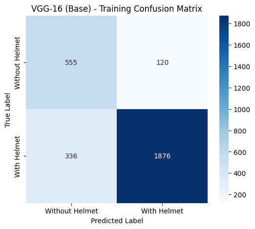

```
20/20 ━━━━━━━━━━━━━━━━━━━━ 0s 15ms/step
```

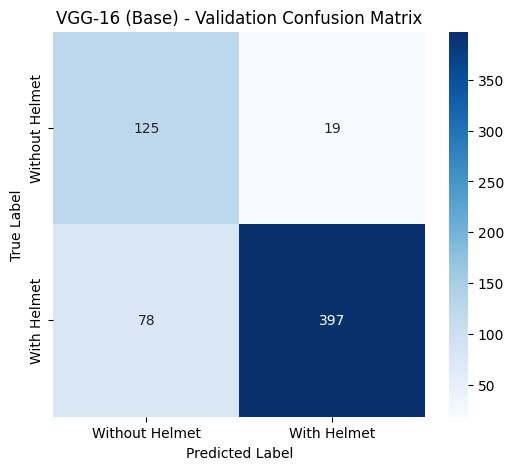

```python
# Reset random state for this notebook
reset_random_state()

# Model 2: Transfer Learning with VGG16 (Base)

from tensorflow.keras.applications.vgg16 import preprocess_input

# Load the VGG16 base model without the top classification layers
vgg_model = VGG16(
    weights='imagenet',
    include_top=False,
    input_shape=(64, 64, 3)
)

# Freeze all layers in the VGG16 base model
for layer in vgg_model.layers:
    layer.trainable = False

# Initialize the transfer learning model
model_2 = Sequential()

# Add the pre-trained VGG16 convolutional base
model_2.add(vgg_model)

# Flatten the extracted feature maps into a 1D vector
model_2.add(Flatten())

# Add a fully connected hidden layer
model_2.add(Dense(32, activation='relu'))

# Add dropout to reduce overfitting
model_2.add(Dropout(0.3))

# Add the output layer for binary classification
model_2.add(Dense(1, activation='sigmoid'))

# Define the Adam optimizer with a lower learning rate for transfer learning
opt = Adam(learning_rate=0.0001)

# Compile the model using binary crossentropy loss and accuracy metric
model_2.compile(
    optimizer=opt,
    loss='binary_crossentropy',
    metrics=['accuracy']
)

# Display the model architecture summary
model_2.summary()

# Compute class weights to handle class imbalance
classes = np.unique(y_train)
class_weights = compute_class_weight(
    class_weight='balanced',
    classes=classes,
    y=y_train
)

class_weight_dict = dict(zip(classes, class_weights))
print("Class weights:", class_weight_dict)

# Create ImageDataGenerators with VGG16 preprocessing
train_datagen = ImageDataGenerator(preprocessing_function=preprocess_input)
val_datagen = ImageDataGenerator(preprocessing_function=preprocess_input)

# Set training parameters
epochs = 10
batch_size = 32

# Train the model
history_2 = model_2.fit(
    train_datagen.flow(
        X_train.astype('float32'),
        y_train,
        batch_size=batch_size,
        seed=812,
        shuffle=True
    ),
    epochs=epochs,
    validation_data=val_datagen.flow(
        X_val.astype('float32'),
        y_val,
        batch_size=batch_size,
        shuffle=False
    ),
    class_weight=class_weight_dict,
    callbacks=[early_stopping],
    verbose=2
)

# Plot training history using helper method
plot_training_history(history_2, title="VGG-16 (Base)")

# Prepare arrays for evaluation using VGG16 preprocessing
X_train_vgg = preprocess_input(X_train.astype('float32').copy())
X_val_vgg = preprocess_input(X_val.astype('float32').copy())

# Evaluate performance on the training and validation set
performance_model_2 = evaluate_model_on_datasets(
    model=model_2,
    X_train=X_train_vgg,
    y_train=y_train,
    X_val=X_val_vgg,
    y_val=y_val,
    model_name="VGG-16 (Base)"
)
```

## **Why these values were chosen**

The values for Model 2 (VGG-16 (Base)) were selected to apply transfer learning using the pre-trained VGG16 model as a feature extractor for the helmet classification task. Since VGG16 was already trained on the large ImageNet dataset, it can provide strong low-level and intermediate visual features such as edges, textures, and object-related patterns that are useful for image classification. The top classification layers of VGG16 were removed by setting include_top=False, allowing the model to adapt its learned features to the helmet dataset. An input size of 64 × 64 was used to remain consistent with the resized images and to reduce computational cost.

All layers in the VGG16 base model were frozen so that the pre-trained weights would be preserved during training. This helps retain the useful features learned from ImageNet while reducing training time and the risk of overfitting on a relatively small dataset. The extracted feature maps were then flattened into a one-dimensional vector using Flatten(), which preserves detailed spatial information from the convolutional output. A dense layer with 32 units and ReLU activation was added to learn task-specific patterns from these extracted features, and Dropout(0.3) was used to reduce overfitting by randomly dropping some neurons during training. Since this is a binary classification problem with labels 0 and 1, the output layer uses 1 neuron with sigmoid activation, which produces a probability for the positive class.

The Adam optimizer with a smaller learning rate of 0.0001 was chosen because transfer learning models generally benefit from slower updates, which help avoid large changes to the learned feature representations. The loss function binary_crossentropy was selected because it is appropriate for binary classification tasks. VGG16-specific preprocessing was applied using preprocess_input so that the images matched the format expected by the pre-trained network. Class weights were used to reduce the effect of class imbalance and help the model pay more attention to the minority class. Early stopping was also included to prevent overfitting by stopping training when the validation loss no longer improved.

## **Short Summary**

Model 2, based on the pre-trained VGG-16 convolutional base, showed moderate performance on both the training and validation sets. Its results were clearly lower than those of Model 1, although the training and validation scores remained quite close, suggesting stable learning and no obvious overfitting.

### Visualizing the predictions

```python
# Visualizing predictions for index 12 and 30
X_val_vgg = preprocess_input(X_val.astype('float32').copy())
plot_two_predictions(12, 30, X_val, X_val_vgg, y_val, model_2)
```

[output not shown]

## Model 3: Transfer Learning with VGG-16 (Base + FFNN)

Let us now extend the transfer learning approach by using VGG-16 as the feature extractor and adding a Feed Forward Neural Network (FFNN) for classification. As before, the convolutional and pooling layers of VGG-16 are used directly and their weights are frozen, so no training is performed on them.

The model has two main parts:

1. Pre-trained Feature Extraction Layers These are the convolutional and pooling layers of VGG-16, which have already learned rich visual patterns from the ImageNet dataset. These layers help extract useful image features such as shapes, textures, and object structure.
2. Fully Connected Classification Layers After flattening the extracted feature maps, a Feed Forward Neural Network is added. These dense layers learn how to combine the extracted features to improve classification performance, while dropout is used to reduce overfitting. The final output layer predicts whether the worker is wearing a helmet or not.

```
Model: "sequential"
```

```
┏━━━━━━━━━━━━━━━━━━━━━━━━━━━━━━━━━┳━━━━━━━━━━━━━━━━━━━━━━━━┳━━━━━━━━━━━━━━━┓
┃ Layer (type)                    ┃ Output Shape           ┃       Param # ┃
┡━━━━━━━━━━━━━━━━━━━━━━━━━━━━━━━━━╇━━━━━━━━━━━━━━━━━━━━━━━━╇━━━━━━━━━━━━━━━┩
│ vgg16 (Functional)              │ (None, 2, 2, 512)      │    14,714,688 │
├─────────────────────────────────┼────────────────────────┼───────────────┤
│ flatten (Flatten)               │ (None, 2048)           │             0 │
├─────────────────────────────────┼────────────────────────┼───────────────┤
│ dense (Dense)                   │ (None, 128)            │       262,272 │
├─────────────────────────────────┼────────────────────────┼───────────────┤
│ dropout (Dropout)               │ (None, 128)            │             0 │
├─────────────────────────────────┼────────────────────────┼───────────────┤
│ dense_1 (Dense)                 │ (None, 64)             │         8,256 │
├─────────────────────────────────┼────────────────────────┼───────────────┤
│ dense_2 (Dense)                 │ (None, 1)              │            65 │
└─────────────────────────────────┴────────────────────────┴───────────────┘
```

```
 Total params: 14,985,281 (57.16 MB)
```

```
 Trainable params: 270,593 (1.03 MB)
```

```
 Non-trainable params: 14,714,688 (56.13 MB)
```

```
Class weights: {np.int64(0): np.float64(2.1385185185185187), np.int64(1): np.float64(0.6525768535262206)}
91/91 - 5s - 57ms/step - accuracy: 0.7724 - loss: 1.8278 - val_accuracy: 0.8853 - val_loss: 0.5381
91/91 - 2s - 24ms/step - accuracy: 0.8680 - loss: 0.7254 - val_accuracy: 0.9079 - val_loss: 0.4802
91/91 - 2s - 24ms/step - accuracy: 0.9106 - loss: 0.4740 - val_accuracy: 0.9079 - val_loss: 0.4525
```

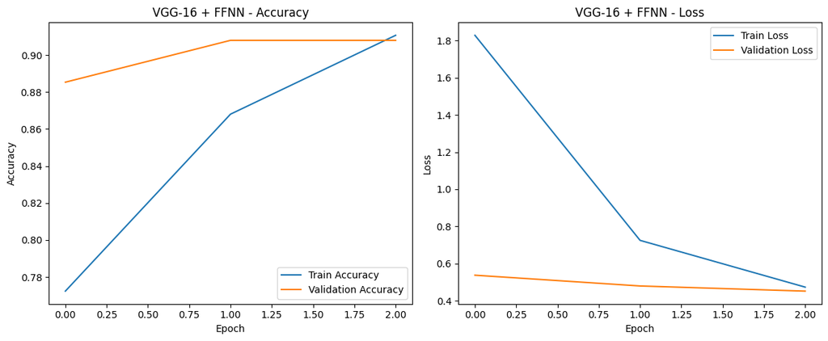

```
91/91 ━━━━━━━━━━━━━━━━━━━━ 2s 17ms/step
20/20 ━━━━━━━━━━━━━━━━━━━━ 0s 15ms/step
VGG-16 + FFNN Performance Summary
```

|  | Accuracy | Recall | Precision | F1 Score |
| --- | --- | --- | --- | --- |
| Train | 0.9148 | 0.9231 | 0.9641 | 0.9432 |
| Validation | 0.8853 | 0.9011 | 0.9469 | 0.9234 |

```
91/91 ━━━━━━━━━━━━━━━━━━━━ 2s 15ms/step
```

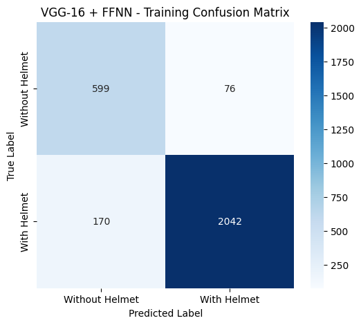

```
20/20 ━━━━━━━━━━━━━━━━━━━━ 0s 16ms/step
```

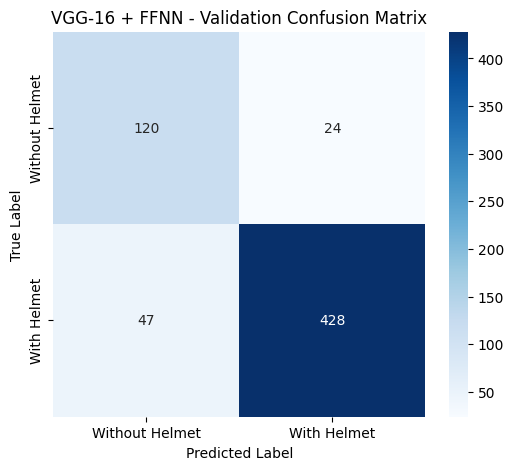

```python
# Reset random state for this notebook
reset_random_state()

# Model 3: Transfer Learning with VGG16 + Feed Forward Neural Network

from tensorflow.keras.applications.vgg16 import preprocess_input

# Load the VGG16 base model without the top classification layers
vgg_model = VGG16(
    weights='imagenet',
    include_top=False,
    input_shape=(64, 64, 3)
)

# Freeze all layers in the VGG16 base model
for layer in vgg_model.layers:
    layer.trainable = False

# Initialize the model
model_3 = Sequential()

# Add the frozen VGG16 convolutional base
model_3.add(vgg_model)

# Flatten the convolutional output
model_3.add(Flatten())

# Add the Feed Forward Neural Network
model_3.add(Dense(128, activation='relu'))
model_3.add(Dropout(0.3))
model_3.add(Dense(64, activation='relu'))

# Add the output layer for binary classification
model_3.add(Dense(1, activation='sigmoid'))

# Define optimizer
opt = Adam(learning_rate=0.0001)

# Compile model
model_3.compile(
    optimizer=opt,
    loss='binary_crossentropy',
    metrics=['accuracy']
)

# Generate summary
model_3.summary()

# Compute class weights to handle class imbalance
classes = np.unique(y_train)
class_weights = compute_class_weight(
    class_weight='balanced',
    classes=classes,
    y=y_train
)

class_weight_dict = dict(zip(classes, class_weights))
print("Class weights:", class_weight_dict)

# Create ImageDataGenerators with VGG16 preprocessing
train_datagen = ImageDataGenerator(preprocessing_function=preprocess_input)
val_datagen = ImageDataGenerator(preprocessing_function=preprocess_input)

# Keep batch size consistent with previous models
batch_size = 32
epochs = 10

# Train the model
history_3 = model_3.fit(
    train_datagen.flow(
        X_train.astype('float32'),
        y_train,
        batch_size=batch_size,
        seed=812,
        shuffle=True
    ),
    epochs=epochs,
    validation_data=val_datagen.flow(
        X_val.astype('float32'),
        y_val,
        batch_size=batch_size,
        shuffle=False
    ),
    class_weight=class_weight_dict,
    callbacks=[early_stopping],
    verbose=2
)

# Plot training history using helper method
plot_training_history(history_3, title="VGG-16 + FFNN")

# Prepare arrays for evaluation using VGG16 preprocessing
X_train_vgg = preprocess_input(X_train.astype('float32').copy())
X_val_vgg = preprocess_input(X_val.astype('float32').copy())

# Evaluate performance on the training and validation set
performance_model_3 = evaluate_model_on_datasets(
    model=model_3,
    X_train=X_train_vgg,
    y_train=y_train,
    X_val=X_val_vgg,
    y_val=y_val,
    model_name="VGG-16 + FFNN"
)
```

## **Why these values were chosen**

The values for Model 3 were selected to combine the pre-trained feature extraction ability of VGG16 with a deeper feed forward neural network for classification. The VGG16 convolutional base was used because it was already trained on the ImageNet dataset and can extract useful low-level and intermediate image features such as edges, textures, and shapes. Its top classification layers were removed by setting include_top=False, allowing the model to adapt these learned visual features to the helmet classification task. The input size of 64 × 64 was kept consistent with the resized dataset in order to reduce computational cost.

All layers in the VGG16 base model were frozen so that the pre-trained weights could be preserved during training. This reduces training time and helps prevent overfitting on a relatively small dataset. The convolutional output was flattened into a one-dimensional vector using Flatten(), which preserves detailed spatial information from the extracted feature maps. Compared with Model 2, a larger feed forward classification head was added by using dense layers with 128 and 64 units. These extra layers were chosen to allow the model to learn more complex task-specific patterns from the VGG16 features before making the final classification. ReLU activation was used in the hidden layers to introduce non-linearity, and Dropout(0.3) was included to reduce overfitting.

The output layer uses 1 neuron with sigmoid activation because this is a binary classification problem with labels 0 and 1. The Adam optimizer with learning rate 0.0001 was chosen to allow the added dense layers to learn efficiently. The loss function binary_crossentropy was selected because it is appropriate for binary classification tasks. VGG16-specific preprocessing was applied using preprocess_input so that the input images matched the format expected by the pre-trained network. Class weights were used to reduce the effect of class imbalance and help the model pay more attention to the minority class. Early stopping was also applied to prevent overfitting by stopping training when the validation loss no longer improved.

## **Short Summary**

Model 3, which combines the VGG-16 base with additional fully connected layers, achieved strong performance on both the training and validation sets. The model performed noticeably better than Model 2, and the confusion matrices suggest that most images in both classes were classified correctly.

The training results are stronger than the validation results, indicating some mild overfitting, but the validation performance is still high. On the validation set, this model achieved 88.53% accuracy, 90.11% recall, 94.69% precision, and an F1-score of 92.34%, making it a clear improvement over the basic VGG-16 model and one of the stronger models for helmet detection.

#### Visualizing the predictions

```python
# Visualizing predictions for index 12 and 30
X_val_vgg = preprocess_input(X_val.astype('float32').copy())
plot_two_predictions(12, 30, X_val, X_val_vgg, y_val, model_3)
```

[output not shown]

## Model 4: Transfer Learning with VGG-16 (Base + FFNN + Data Augmentation)

- In most of the real-world case studies, it is challenging to acquire a large number of images and then train CNNs.
- To overcome this problem, one approach we might consider is **Data Augmentation**.
- CNNs have the property of **translational invariance**, which means they can recognise an object even if its appearance shifts translationally in some way. - Taking this attribute into account, we can augment the images using the techniques listed below
  - Horizontal Flip (should be set to True/False)
  - Vertical Flip (should be set to True/False)
  - Height Shift (should be between 0 and 1)
  - Width Shift (should be between 0 and 1)
  - Rotation (should be between 0 and 180)
  - Shear (should be between 0 and 1)
  - Zoom (should be between 0 and 1) etc.

Remember, **data augmentation should not be used in the validation/test data set**.

Let us now build a transfer learning model using VGG-16 as the base model, along with a Feed Forward Neural Network (FFNN) and data augmentation. As in the previous transfer learning model, the convolutional and pooling layers of VGG-16 are used as a feature extractor and their weights are frozen.

The model has three main parts:

1. Pre-trained Feature Extraction Layers The convolutional and pooling layers of VGG-16 are used to extract meaningful visual features from the images. Since these layers were pre-trained on the ImageNet dataset, they already contain useful feature representations.
2. Fully Connected Classification Layers After flattening the extracted features, dense layers are added to form a Feed Forward Neural Network. These layers learn how to classify the extracted features into the two target classes.
3. Data Augmentation Data augmentation is applied only to the training set to artificially increase image variation. This helps the model generalize better by exposing it to slightly modified versions of the original images, such as shifted, rotated, sheared, and zoomed images.

```
Model: "sequential"
```

```
┏━━━━━━━━━━━━━━━━━━━━━━━━━━━━━━━━━┳━━━━━━━━━━━━━━━━━━━━━━━━┳━━━━━━━━━━━━━━━┓
┃ Layer (type)                    ┃ Output Shape           ┃       Param # ┃
┡━━━━━━━━━━━━━━━━━━━━━━━━━━━━━━━━━╇━━━━━━━━━━━━━━━━━━━━━━━━╇━━━━━━━━━━━━━━━┩
│ vgg16 (Functional)              │ (None, 2, 2, 512)      │    14,714,688 │
├─────────────────────────────────┼────────────────────────┼───────────────┤
│ flatten (Flatten)               │ (None, 2048)           │             0 │
├─────────────────────────────────┼────────────────────────┼───────────────┤
│ dense (Dense)                   │ (None, 128)            │       262,272 │
├─────────────────────────────────┼────────────────────────┼───────────────┤
│ dropout (Dropout)               │ (None, 128)            │             0 │
├─────────────────────────────────┼────────────────────────┼───────────────┤
│ dense_1 (Dense)                 │ (None, 64)             │         8,256 │
├─────────────────────────────────┼────────────────────────┼───────────────┤
│ dense_2 (Dense)                 │ (None, 1)              │            65 │
└─────────────────────────────────┴────────────────────────┴───────────────┘
```

```
 Total params: 14,985,281 (57.16 MB)
```

```
 Trainable params: 270,593 (1.03 MB)
```

```
 Non-trainable params: 14,714,688 (56.13 MB)
```

```
Class weights: {np.int64(0): np.float64(2.1385185185185187), np.int64(1): np.float64(0.6525768535262206)}
91/91 - 9s - 96ms/step - accuracy: 0.7399 - loss: 2.0759 - val_accuracy: 0.8756 - val_loss: 0.6592
91/91 - 7s - 78ms/step - accuracy: 0.8310 - loss: 0.9360 - val_accuracy: 0.9176 - val_loss: 0.4123
91/91 - 6s - 69ms/step - accuracy: 0.8490 - loss: 0.7400 - val_accuracy: 0.9063 - val_loss: 0.4338
```

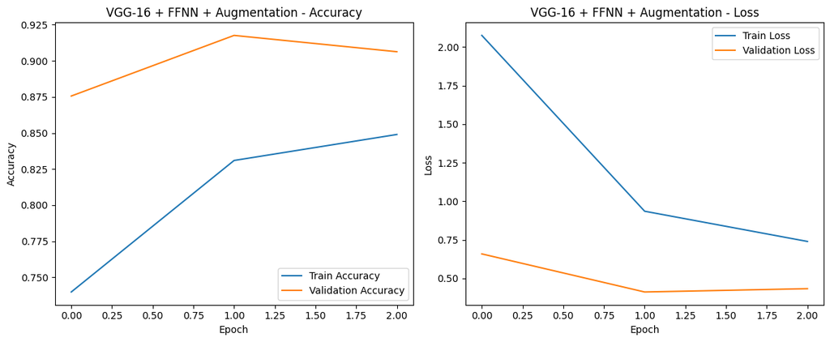

```
91/91 ━━━━━━━━━━━━━━━━━━━━ 2s 17ms/step
20/20 ━━━━━━━━━━━━━━━━━━━━ 0s 15ms/step
VGG-16 + FFNN + Augmentation Performance Summary
```

|  | Accuracy | Recall | Precision | F1 Score |
| --- | --- | --- | --- | --- |
| Train | 0.8722 | 0.8684 | 0.9610 | 0.9124 |
| Validation | 0.8756 | 0.8758 | 0.9585 | 0.9153 |

```
91/91 ━━━━━━━━━━━━━━━━━━━━ 2s 15ms/step
```

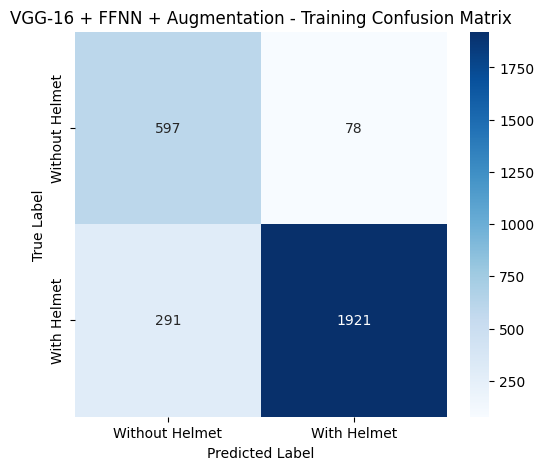

```
20/20 ━━━━━━━━━━━━━━━━━━━━ 0s 17ms/step
```

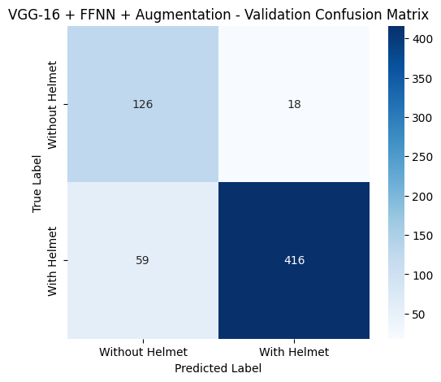

```python
# Reset random state for this notebook
reset_random_state()

# Model 4: Transfer Learning with VGG16 + FFNN + Data Augmentation

from tensorflow.keras.applications.vgg16 import preprocess_input

# Load the VGG16 base model without the top classification layers
vgg_model = VGG16(
    weights='imagenet',
    include_top=False,
    input_shape=(64, 64, 3)
)

# Freeze all layers in the VGG16 base model
for layer in vgg_model.layers:
    layer.trainable = False

# Initialize the model
model_4 = Sequential()

# Add the frozen VGG16 convolutional base
model_4.add(vgg_model)

# Flatten the output of the VGG16 model
model_4.add(Flatten())

# Add the Feed Forward Neural Network
model_4.add(Dense(128, activation='relu'))
model_4.add(Dropout(0.3))
model_4.add(Dense(64, activation='relu'))

# Add the output layer for binary classification
model_4.add(Dense(1, activation='sigmoid'))

# Define optimizer
opt = Adam(learning_rate=0.0001)

# Compile model
model_4.compile(
    optimizer=opt,
    loss='binary_crossentropy',
    metrics=['accuracy']
)

# Generate the summary of the model
model_4.summary()

# Compute class weights to handle class imbalance
classes = np.unique(y_train)
class_weights = compute_class_weight(
    class_weight='balanced',
    classes=classes,
    y=y_train
)

class_weight_dict = dict(zip(classes, class_weights))
print("Class weights:", class_weight_dict)

# Apply data augmentation together with VGG16 preprocessing
train_datagen = ImageDataGenerator(
    preprocessing_function=preprocess_input,
    rotation_range=20,
    fill_mode='nearest',
    width_shift_range=0.2,
    height_shift_range=0.2,
    shear_range=0.2,
    zoom_range=0.2
)

# Validation data should only be preprocessed, not augmented
val_datagen = ImageDataGenerator(preprocessing_function=preprocess_input)

# Keep settings consistent with previous models
batch_size = 32
epochs = 10

# Train the model
history_4 = model_4.fit(
    train_datagen.flow(
        X_train.astype('float32'),
        y_train,
        batch_size=batch_size,
        seed=812,
        shuffle=True
    ),
    epochs=epochs,
    validation_data=val_datagen.flow(
        X_val.astype('float32'),
        y_val,
        batch_size=batch_size,
        shuffle=False
    ),
    class_weight=class_weight_dict,
    callbacks=[early_stopping],
    verbose=2
)

# Plot training history using helper method
plot_training_history(history_4, title="VGG-16 + FFNN + Augmentation")

# Prepare arrays for evaluation using VGG16 preprocessing
X_train_vgg = preprocess_input(X_train.astype('float32').copy())
X_val_vgg = preprocess_input(X_val.astype('float32').copy())

# Evaluate performance on the training and validation set
performance_model_4 = evaluate_model_on_datasets(
    model=model_4,
    X_train=X_train_vgg,
    y_train=y_train,
    X_val=X_val_vgg,
    y_val=y_val,
    model_name="VGG-16 + FFNN + Augmentation"
)
```

## **Why these values were chosen**

The values for Model 4 were selected to extend the VGG16-based transfer learning approach by adding both a deeper feed forward classification head and data augmentation. The pre-trained VGG16 convolutional base was used because it can extract useful low-level and intermediate image features learned from the large ImageNet dataset. Its top classification layers were removed by setting include_top=False, allowing the extracted visual features to be adapted to the helmet classification task. The input size of 64 × 64 was kept consistent with the resized dataset in order to reduce computational cost.

All layers in the VGG16 base model were frozen so that the pre-trained weights could be preserved during training. This helps reduce training time and lowers the risk of overfitting on a relatively small dataset. The convolutional output was flattened into a one-dimensional vector using Flatten(), which preserves spatial information from the extracted feature maps. A feed forward neural network with dense layers of 128 and 64 units was added so the model could learn more complex task-specific patterns from the VGG16 features. ReLU activation was used in the hidden layers to introduce non-linearity, and Dropout(0.3) was included to reduce overfitting.

Data augmentation was introduced in Model 4 to improve generalization by exposing the model to varied versions of the training images. Random transformations such as rotation, width and height shifts, shear, and zoom were applied to simulate realistic variation in viewpoint and positioning. This was intended to make the model more robust to changes in worker pose, camera angle, and scene conditions. Validation images were not augmented so that model performance could be measured on unmodified data. VGG16-specific preprocessing was also applied using preprocess_input so that the input images matched the format expected by the pre-trained network.

The output layer uses 1 neuron with sigmoid activation because this is a binary classification problem with labels 0 and 1. The Adam optimizer with learning rate 0.0001 was chosen to allow the added dense layers to learn efficiently. The loss function binary_crossentropy was selected because it is appropriate for binary classification tasks. Class weights were used to reduce the effect of class imbalance and help the model pay more attention to the minority class. Early stopping was also applied to prevent overfitting by stopping training when the validation loss no longer improved.

## **Short Summary**

Model 4, which combines VGG-16, additional fully connected layers, and data augmentation, achieved good overall performance on both the training and validation sets. The confusion matrices show that the model correctly classified most images in both classes, especially the With Helmet class.

Compared with Model 3, this model produced slightly lower training and validation performance, but the smaller gap between training and validation results suggests that augmentation helped improve generalization and reduce overfitting. On the validation set, this model achieved 87.56% accuracy, 87.58% recall, 95.85% precision, and an F1-score of 91.53%, making it a robust model, although its performance was still slightly lower than Model 3.

#### Visualizing the predictions

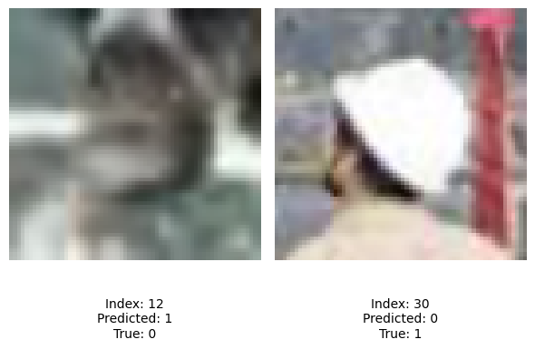

```python
# Visualizing predictions for index 12 and 30
X_val_vgg = preprocess_input(X_val.astype('float32').copy())
plot_two_predictions(12, 30, X_val, X_val_vgg, y_val, model_4)
```

- Two validation images were selected to inspect the predictions made by the VGG-16 + FFNN + Augmentation model. For image index 12, the model predicted class 1, which does not matche true label 0, so this image was misclassified. For image index 30, the model predicted class 0, which also does not matche true label 1, so this image was misclassified as well.

# **Model Performance Comparison and Final Model Selection**

```python
# Extract the validation row from each model's performance table
model_1_comp = performance_model_1.loc[['Validation']].copy()
model_1_comp.index = ['CNN from Scratch']

model_2_comp = performance_model_2.loc[['Validation']].copy()
model_2_comp.index = ['VGG16 Base']

model_3_comp = performance_model_3.loc[['Validation']].copy()
model_3_comp.index = ['VGG16 Base + FFNN']

model_4_comp = performance_model_4.loc[['Validation']].copy()
model_4_comp.index = ['VGG16 Base + FFNN + Augmentation']

# Combine all model performances into one table
final_model_comparison = pd.concat([
    model_1_comp,
    model_2_comp,
    model_3_comp,
    model_4_comp
])

# Display the comparison table
print("Validation Performance Comparison of All Models")
display(final_model_comparison.round(4))

# Select the best model based on validation F1 Score
best_model_name = final_model_comparison['F1 Score'].idxmax()
best_model_metrics = final_model_comparison.loc[[best_model_name]]

print("Best Model Based on Validation F1 Score:")
display(best_model_metrics.round(4))
```

```
Validation Performance Comparison of All Models
```

|  | Accuracy | Recall | Precision | F1 Score |
| --- | --- | --- | --- | --- |
| CNN from Scratch | 0.9047 | 0.9074 | 0.9664 | 0.9359 |
| VGG16 Base | 0.8433 | 0.8358 | 0.9543 | 0.8911 |
| VGG16 Base + FFNN | 0.8853 | 0.9011 | 0.9469 | 0.9234 |
| VGG16 Base + FFNN + Augmentation | 0.8756 | 0.8758 | 0.9585 | 0.9153 |

```
Best Model Based on Validation F1 Score:
```

|  | Accuracy | Recall | Precision | F1 Score |
| --- | --- | --- | --- | --- |
| CNN from Scratch | 0.9047 | 0.9074 | 0.9664 | 0.9359 |

The validation performance of all four models was compared using accuracy, recall, precision, and F1-score to identify the most effective approach for helmet detection. Among all models, CNN from Scratch achieved the best overall performance, with a validation accuracy of 90.47%, recall of 90.74%, precision of 96.64%, and the highest F1-score of 93.59%. This indicates that the CNN model provided the best balance between correctly identifying helmet and non-helmet images while maintaining strong overall classification performance.

The VGG16 Base model produced the lowest validation performance, with an F1-score of 89.11%, showing that using the frozen pre-trained convolutional base alone was not sufficient for this task. Adding fully connected layers in VGG16 Base + FFNN improved the results considerably, increasing the F1-score to 92.34%, which made it the second-best model. The VGG16 Base + FFNN + Augmentation model also performed well, with an F1-score of 91.53%, but it still did not surpass the CNN from Scratch.

Based on the validation F1-score, CNN from Scratch was selected as the final model, since it outperformed all other models across the key evaluation metrics. Its strong recall and precision make it the most reliable choice for helmet detection, especially in a safety-related application where correctly identifying violations is important.

## Test Performance

```
20/20 ━━━━━━━━━━━━━━━━━━━━ 0s 5ms/step
20/20 ━━━━━━━━━━━━━━━━━━━━ 0s 3ms/step
```

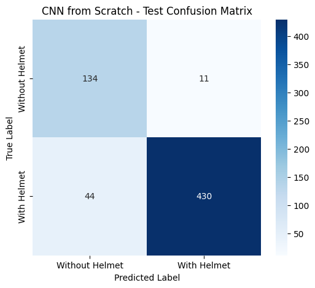

```
20/20 ━━━━━━━━━━━━━━━━━━━━ 1s 21ms/step
20/20 ━━━━━━━━━━━━━━━━━━━━ 0s 15ms/step
```

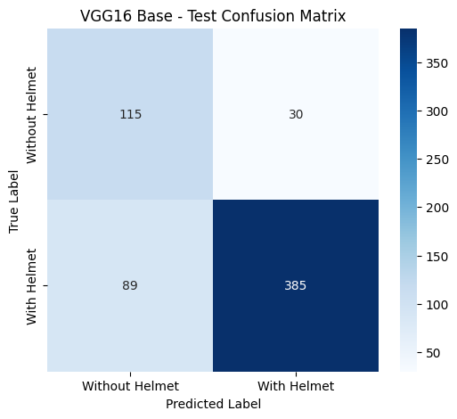

```
20/20 ━━━━━━━━━━━━━━━━━━━━ 0s 18ms/step
20/20 ━━━━━━━━━━━━━━━━━━━━ 0s 15ms/step
```

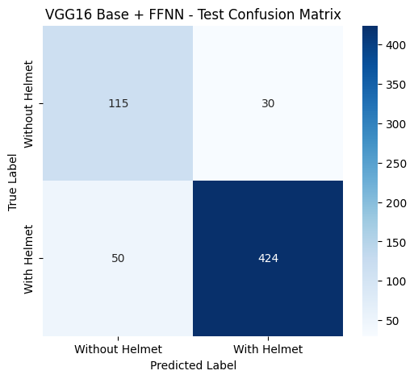

```
20/20 ━━━━━━━━━━━━━━━━━━━━ 0s 16ms/step
20/20 ━━━━━━━━━━━━━━━━━━━━ 0s 15ms/step
```

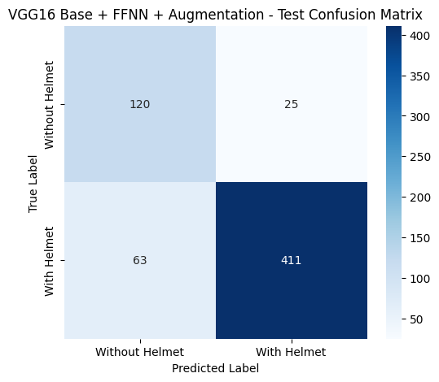

```
Test Performance Comparison of All Models
```

|  | Accuracy | Recall | Precision | F1 Score |
| --- | --- | --- | --- | --- |
| CNN from Scratch | 0.9111 | 0.9072 | 0.9751 | 0.9399 |
| VGG16 Base | 0.8078 | 0.8122 | 0.9277 | 0.8661 |
| VGG16 Base + FFNN | 0.8708 | 0.8945 | 0.9339 | 0.9138 |
| VGG16 Base + FFNN + Augmentation | 0.8578 | 0.8671 | 0.9427 | 0.9033 |

```
Best Model Based on Test F1 Score:
```

|  | Accuracy | Recall | Precision | F1 Score |
| --- | --- | --- | --- | --- |
| CNN from Scratch | 0.9111 | 0.9072 | 0.9751 | 0.9399 |

```python
# Since the CNN model was trained on normalized images,
# it must be evaluated on the normalized test set.

# The VGG-based models were trained using preprocess_input,
# so they must be evaluated on VGG-preprocessed test images.

from tensorflow.keras.applications.vgg16 import preprocess_input

# Prepare the test set for the VGG-based models
X_test_vgg = preprocess_input(X_test.astype('float32').copy())

# Create a dictionary so each model is evaluated on the correct test input
test_inputs = {
    "CNN from Scratch": X_test_normalized,
    "VGG16 Base": X_test_vgg,
    "VGG16 Base + FFNN": X_test_vgg,
    "VGG16 Base + FFNN + Augmentation": X_test_vgg
}

trained_models = {
    "CNN from Scratch": model_1,
    "VGG16 Base": model_2,
    "VGG16 Base + FFNN": model_3,
    "VGG16 Base + FFNN + Augmentation": model_4
}

# Evaluate each model on the test set
test_results = []

for model_name, model in trained_models.items():

    # Select the correct test input representation
    X_test_input = test_inputs[model_name]

    # Use the existing helper function to compute metrics
    test_perf = model_performance_classification(model, X_test_input, y_test)
    test_perf.index = [model_name]

    # Store the result
    test_results.append(test_perf)

    # Plot confusion matrix for each model on the test set
    plot_confusion_matrix(
        model,
        X_test_input,
        y_test,
        title=f"{model_name} - Test Confusion Matrix"
    )

# Combine all test results into one table
final_test_comparison = pd.concat(test_results)

# Display the complete test performance table
print("Test Performance Comparison of All Models")
display(final_test_comparison.round(4))

# Select the best model based on test F1-score
best_test_model_name = final_test_comparison['F1 Score'].idxmax()
best_test_model_metrics = final_test_comparison.loc[[best_test_model_name]]

print("Best Model Based on Test F1 Score:")
display(best_test_model_metrics.round(4))
```

The performance of all four models was evaluated on the test set using accuracy, recall, precision, and F1-score to measure how well they generalize to unseen data. Among all models, CNN from Scratch achieved the best overall test performance, with 91.11% accuracy, 90.72% recall, 97.51% precision, and an F1-score of 93.99%. This shows that the CNN model generalized very well and provided the best balance between precision and recall on unseen images.

The VGG16 Base model showed the lowest test performance, with an F1-score of 86.61%, indicating that the frozen pre-trained VGG16 base alone was not sufficient for this task. The VGG16 Base + FFNN model performed much better, achieving an F1-score of 91.38%, which made it the second-best model on the test set. The VGG16 Base + FFNN + Augmentation model also produced solid results, with an F1-score of 90.33%, but it still remained below the CNN from Scratch model.

Based on the test F1-score, CNN from Scratch was selected as the best final model, since it outperformed all other models on unseen data. Its strong precision and recall make it the most reliable model for helmet detection, especially in a real-world safety monitoring application where accurate identification is essential.

# **Actionable Insights & Recommendations**

- The CNN from Scratch model emerged as the best overall model because it achieved the highest validation F1-score among all four models. This suggests that, for this dataset, a relatively simple CNN was able to learn the relevant visual patterns more effectively than the transfer learning approaches.
- The VGG16 Base model produced the weakest performance, indicating that using the frozen pre-trained convolutional base with only a small classification head was not sufficient for this helmet detection task.
- Adding a deeper feed forward neural network in Model 3 improved the VGG16-based approach considerably, showing that richer classification layers helped extract more useful task-specific information from the pre-trained features.
- Model 4, which used data augmentation, showed slightly lower performance than Model 3, but it still remained robust. This suggests that augmentation helped improve generalization, although in this case it did not outperform the CNN from Scratch.
- Since this is an imbalanced classification problem, F1-score, precision, and recall are more informative than accuracy alone. In workplace safety applications, recall is especially important because missing a worker without a helmet can have serious consequences.
- Based on the current results, the CNN from Scratch model is recommended as the final model for deployment because it achieved the best balance between recall, precision, and F1-score on the validation set, and performed best on the test set.
- For future improvement, one useful next step would be to tune the classification threshold instead of using the default 0.5. This may help improve recall for the Without Helmet class, which is especially important in a safety monitoring system.
- Another recommendation is to fine-tune the upper layers of VGG16 instead of keeping the full convolutional base frozen. This may allow the transfer learning models to adapt better to the helmet dataset and potentially outperform the CNN baseline.
- Additional improvements may also come from testing other pre-trained models such as ResNet50, MobileNet, or EfficientNet, which often provide stronger feature extraction and better transfer learning performance than VGG16.
- Finally, collecting more images for the Without Helmet class would likely improve model balance and minority-class detection, making the final system more reliable in real-world safety applications.

Overall, the CNN from Scratch model was selected as the final model because it achieved the best validation and test F1-score, showing strong generalization and reliable helmet detection performance. This makes it the most suitable choice for deployment in workplace safety monitoring.

# **Export notebook to .HTML**

Power Ahead!